# Exercício Computacional 5

Importando libraries:

```r
library(tidyverse)
```

Setando o diretório corrente:

```r
setwd(dirname(rstudioapi::getActiveDocumentContext()$path))
getwd()
```

```
[1] "/Users/adrianosastre/Dropbox/Data Science/Exercícios/datascience-exercises-20200418-conceitos-ml/Exercícios-Computacionais/5"
```

Conceito explorado: MSE - Mean Square Error

Considere o seguinte modelo de geração de dados mostrado abaixo:

y = h(x)+e

Nesse modelo, h(x) = 3x+30 consiste na função hipótese verdadeira, muitas vezes desconhecida na prática de ML, e e é um termo que expressa a incerteza entre os valores da função hipótese verdadeira e a variável de saída ou resposta y. Estatisticamente, e é interpretado como um ruído, que nesse exercício segue a distribuição de probabilidade Gaussiana com média m = 0 e desvio padrão s = 15. A notação em negrito usada ocorre em função de (1.3) ser um modelo vetorial de dados. A variável explanatória x usada será um vetor de valores inteiros de zero (1) a cem (100). Logo, o modelo de dados é formado pelos vetores y, h(x) e e, sendo cada um com dimensões (número de linhas e colunas) de 100

```r
# Geração do Modelo de Dados

# Número de amostras
n = 100

# Crie um vetor de índices x variando de 1 a 100. Utilize a função seq - sequence
# x = seq(from = 1, to = 100, by = 1)
x = seq(1, 100, length.out = n)
x
```

```
  [1]   1   2   3   4   5   6   7   8   9  10  11  12  13  14  15  16  17  18  19  20  21  22  23  24  25  26  27
 [28]  28  29  30  31  32  33  34  35  36  37  38  39  40  41  42  43  44  45  46  47  48  49  50  51  52  53  54
 [55]  55  56  57  58  59  60  61  62  63  64  65  66  67  68  69  70  71  72  73  74  75  76  77  78  79  80  81
 [82]  82  83  84  85  86  87  88  89  90  91  92  93  94  95  96  97  98  99 100
```

```r
# Função hipótese verdadeira
h_x <- 3*x + 30
h_x
```

[output not shown]

```r
# Ruído
set.seed(123)
?rnorm
epsilon <- rnorm(n, 0, 15)
epsilon
```

```
  [1]  -8.40713470  -3.45266234  23.38062471   1.05762587   1.93931603  25.72597480   6.91374309 -18.97591852
  [9] -10.30279278  -6.68492955  18.36122696   5.39720741   6.01157176   1.66024074  -8.33761702  26.80369705
 [17]   7.46775717 -29.49925735  10.52033852  -7.09187112 -16.01735559  -3.26962372 -15.39006672 -10.93336844
 [25]  -9.37558902 -25.30039966  12.56680567   2.30059677 -17.07205406  18.80722382   6.39696332  -4.42607224
 [33]  13.42688492  13.17200231  12.32371622  10.32960381   8.30876480  -0.92867566  -4.58943996  -5.70706502
 [41] -10.42060468  -3.11875917 -18.98094527  32.53433948  18.11942997 -16.84662875  -6.04327253  -6.99983030
 [49]  11.69947678  -1.25053600   3.79977771  -0.42820133  -0.64305686  20.52903426  -3.38656478  22.74705907
 [57] -23.23129206   8.76920624   1.85781366   3.23912353   5.69459224  -7.53485180  -4.99811076 -15.27863075
 [65] -16.07686840   4.55292962   6.72314668   0.79506340  13.83401202  30.75127028  -7.36546749 -34.63753313
 [73]  15.08607787 -10.63801144 -10.32012925  15.38357055  -4.27159511 -18.31076568   2.71955220  -2.08337044
 [81]   0.08646279   5.77920602  -5.55990048   9.66564823  -3.30729843   4.97672946  16.45258520   6.52772236
 [89]  -4.88897378  17.23211428  14.90255784   8.22595439   3.58097603  -9.41859114  20.40978673  -9.00389381
 [97]  32.80999490  22.98915939  -3.53550539 -15.39631350
```

```r
# Variável de saída
y <- h_x + epsilon
y
```

```
  [1]  24.59287  32.54734  62.38062  43.05763  46.93932  73.72597  57.91374  35.02408  46.69721  53.31507  81.36123
 [12]  71.39721  75.01157  73.66024  66.66238 104.80370  88.46776  54.50074  97.52034  82.90813  76.98264  92.73038
 [23]  83.60993  91.06663  95.62441  82.69960 123.56681 116.30060  99.92795 138.80722 129.39696 121.57393 142.42688
 [34] 145.17200 147.32372 148.32960 149.30876 143.07132 142.41056 144.29293 142.57940 152.88124 140.01905 194.53434
 [45] 183.11943 151.15337 164.95673 167.00017 188.69948 178.74946 186.79978 185.57180 188.35694 212.52903 191.61344
 [56] 220.74706 177.76871 212.76921 208.85781 213.23912 218.69459 208.46515 214.00189 206.72137 208.92313 232.55293
 [67] 237.72315 234.79506 250.83401 270.75127 235.63453 211.36247 264.08608 241.36199 244.67987 273.38357 256.72840
 [78] 245.68923 269.71955 267.91663 273.08646 281.77921 273.44010 291.66565 281.69270 292.97673 307.45259 300.52772
 [89] 292.11103 317.23211 317.90256 314.22595 312.58098 302.58141 335.40979 308.99611 353.80999 346.98916 323.46449
[100] 314.60369
```

2. Faça um gráfico de dispersão da variável explanatória x com saída conhecida y.

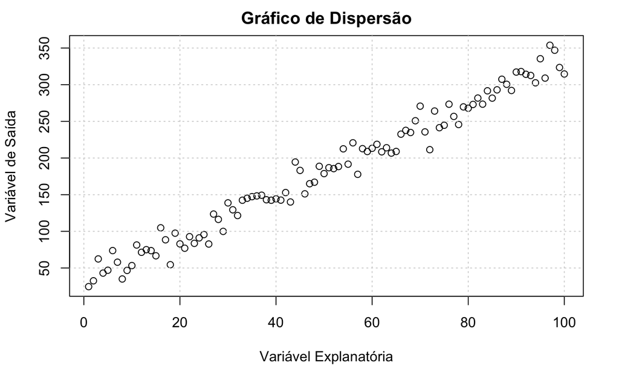

```r
plot(x,y,col=1, pch=1, main = 'Gráfico de Dispersão',
     col.main = 'black',
     xlab = 'Variável Explanatória',
     ylab = 'Variável de Saída')
grid()
```

3. Obtenha o histograma relacionado com a variável de saída y.

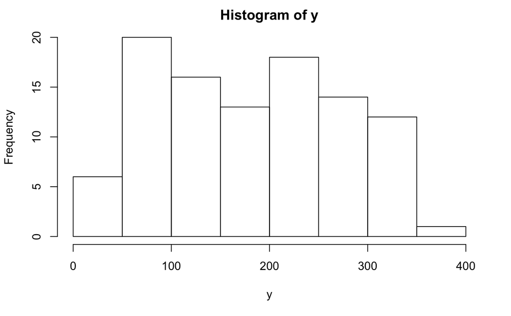

```r
hist(y)
```

4. A equação do MSE, mostrada abaixo, é uma métrica de desempenho relacionada com qual tipo de tarefa de aprendizagem de máquina?

RESPOSTA = Está relacionada a uma tarefa do tipo Regressão da Aprendizagem Supervisionada.

5. Faça a estimação do erro quadrático médio do modelo proposto pelos cientistas.

```r
# Função hipótese Estimada
h_x_estimado <- 2.4*x + 40
h_x_estimado
```

```
  [1]  42.4  44.8  47.2  49.6  52.0  54.4  56.8  59.2  61.6  64.0  66.4  68.8  71.2  73.6  76.0  78.4  80.8  83.2
 [19]  85.6  88.0  90.4  92.8  95.2  97.6 100.0 102.4 104.8 107.2 109.6 112.0 114.4 116.8 119.2 121.6 124.0 126.4
 [37] 128.8 131.2 133.6 136.0 138.4 140.8 143.2 145.6 148.0 150.4 152.8 155.2 157.6 160.0 162.4 164.8 167.2 169.6
 [55] 172.0 174.4 176.8 179.2 181.6 184.0 186.4 188.8 191.2 193.6 196.0 198.4 200.8 203.2 205.6 208.0 210.4 212.8
 [73] 215.2 217.6 220.0 222.4 224.8 227.2 229.6 232.0 234.4 236.8 239.2 241.6 244.0 246.4 248.8 251.2 253.6 256.0
 [91] 258.4 260.8 263.2 265.6 268.0 270.4 272.8 275.2 277.6 280.0
```

```r
MSE = (1/n)*sum(((y - h_x_estimado)^2))
MSE
```

```
[1] 992.2213
```

6. Faça uma análise: o modelo proposto é plausível para explicar os dados? De quais fatores esse desempenho depende?